# P1805_hw5_jn2761

jiaying Ning

11/14/2020

## problem 2

### Import data

```r
#Create a tidy dataframe containing data from all participants, including the subject ID, arm, and observations over time
df =
  tibble(
    path = list.files("data"), #created a dataframe containing all file names
  ) %>%
  mutate(
    path = str_c("data/", path),
    data = map(path,read.csv)) %>% #Iterate over file names and read in data for each subject using purrr::map and saving the result as a new variable in the dataframe
  unnest() %>%
   mutate(path=gsub("data/","",path), #reformat data
          path=gsub(".csv","",path)) %>%
   separate(path, c("control_arm","subject_id"), sep = "([_])") %>%
  relocate(subject_id,control_arm) %>%
   pivot_longer( #Tidy the result; manipulate file names to include control arm and subject ID
    week_1:week_8,
    names_to = "week",
    names_prefix = "week_",
    values_to = "observation")
```

### plot 1:spaghetti plot showing observations on each subject over time, and comment on differences between groups.

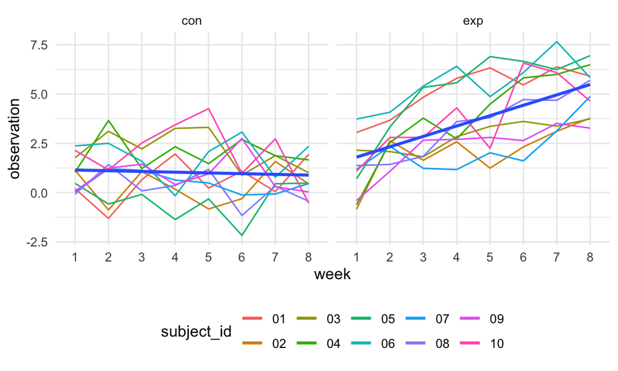

```r
df %>%
  group_by(subject_id)%>%
  ggplot(aes(x=week,y=observation,group=subject_id,color=subject_id))+
  geom_line() +
  stat_smooth(aes(group = 1),method = "lm", se = FALSE)+
  facet_grid(. ~ control_arm)
```

```r
exp = df %>%
  group_by(control_arm,subject_id)%>%
  filter(control_arm=="exp")
```

### plot 2:spaghetti plot showing observations on each subject over time, and comment on differences between groups.

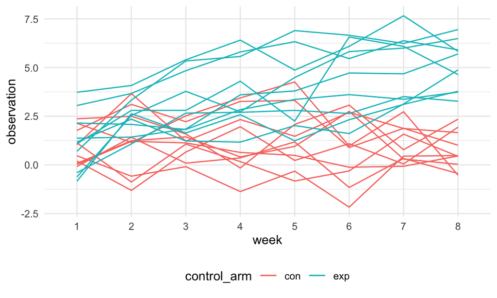

```r
df %>%
  group_by(control_arm,subject_id)%>%
  filter(control_arm=="con")%>%
  ggplot(aes(x=week,y=observation,group=subject_id,color=control_arm))+
  geom_line() +
  geom_line(aes(x=exp$week,y=exp$observation,group=exp$subject_id,color=exp$control_arm))
```

**Overall, observation value seems to be higher as time pass by for the experimental group, and there seems to no correlation between time and observations for the control group.**

## problem3

making sure the table I am trying to create work before putting into function

```r
tidy(t.test(rnorm(n=30,mean=0,sd=5))) %>%
  select(p.value) %>%
  mutate(x=list(rnorm(n=30,mean=0,sd=5)),
         mu=0,
         mean = mean(x[[1]]))%>%
 select(-x)
```

```
## # A tibble: 1 x 3
##   p.value    mu  mean
##     <dbl> <dbl> <dbl>
## 1   0.681     0 0.525
```

```r
sim_norm = function(size=30, mu, sigma = 5) {


tidy(t.test(rnorm(n=size, mean = mu, sd = sigma)),mu = 0,conf,leve=0.95,alternative="two.sided") %>%
  select(p.value) %>%
  mutate(x=list(rnorm(n=size, mean = mu, sd = sigma)),
         mean = mean(x[[1]]))%>%
 select(-x)


}
```

try to simulate data, sumulate data with mu=0 first, created 5000 dataset with true mean=0

```r
mu_c =c(1:7)
output = vector("list", length = 6)


  output[[1]] =  rerun(5000, sim_norm(mu = mu_c[1]-1)) %>%
  bind_rows()

  output[[1]]
```

```
## # A tibble: 5,000 x 2
##    p.value    mean
##      <dbl>   <dbl>
##  1  0.352   0.0197
##  2  0.749   0.838
##  3  0.0774  1.12
##  4  0.577   1.25
##  5  0.0470 -0.302
##  6  0.140  -0.495
##  7  0.452  -0.981
##  8  0.0537  0.508
##  9  0.155  -1.25
## 10  0.615  -0.619
## # … with 4,990 more rows
```

testing for loop for simulating 10 dataset for mu from 0~6

```r
for (i in 1:7) {
  output[[i]] =  rerun(10, sim_norm(mu = mu_c[i]-1)) %>%
  bind_rows()}
```

creating datframe containing true mean(0-6), p-value for each simulated dataset,and sample mean

```r
sample_results =
tibble(
  mu_c =c(1:7)
) %>%
  mutate(
    output_list = map(.x = mu_c-1,~rerun(5000,sim_norm(mu=.x))), #function inside of a function #rerun a 100 times
    estmate_df = map(output_list, bind_rows)
  )  %>%
  select(-output_list) %>% #i dont want this anymore
  unnest(estmate_df) %>%
  mutate(decision = ifelse(p.value<0.05,"reject","accept"), #adding categorical variable decision to mark whether each sample is rejected or accepted from null
         mu_c=mu_c-1)
```

### plot showing the proportion of times the null was rejected (the power of the test) on the y axis and the true value of μ on the x axis

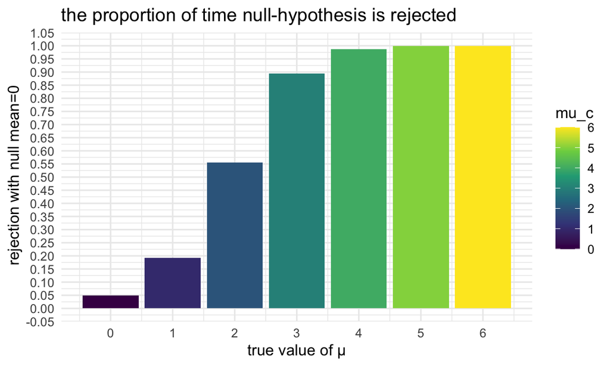

```r
sample_results%>%
  group_by(decision,mu_c) %>%
  filter(decision=="reject") %>%
  summarise(n_reject=n()) %>%
   mutate(freq_reject= n_reject/5000)%>%
  ggplot(aes(x=mu_c, y=freq_reject,fill=mu_c)) +
  geom_bar(stat = "identity") +
  scale_x_continuous(
    breaks = c(0:6)) +
  scale_y_continuous(
   n.breaks = 20) +
  labs(titles = "the proportion of time null-hypothesis is rejected",
        x = "true value of μ",
       y= " rejection with null mean=0") +
  theme(legend.position = "right")
```

**As the true mean increase, we can see that the proportion of time we reject the test with null (mu=0) also increase. which means that the power of the test increase as the true mean deviate away from the hypothesis mean.**

### plot showing the average estimate of μ̂ in all samples and samples for which the null was rejected on the y axis and the true value of μ on the x axis

```r
all=
sample_results%>%
  group_by(mu_c)%>%
  summarise(mean_mu = mean(mean),n=n())
reject=
sample_results%>%
    filter(decision =="reject") %>%
  group_by(mu_c)%>%
  summarise(mean_mu = mean(mean),n=n())
```

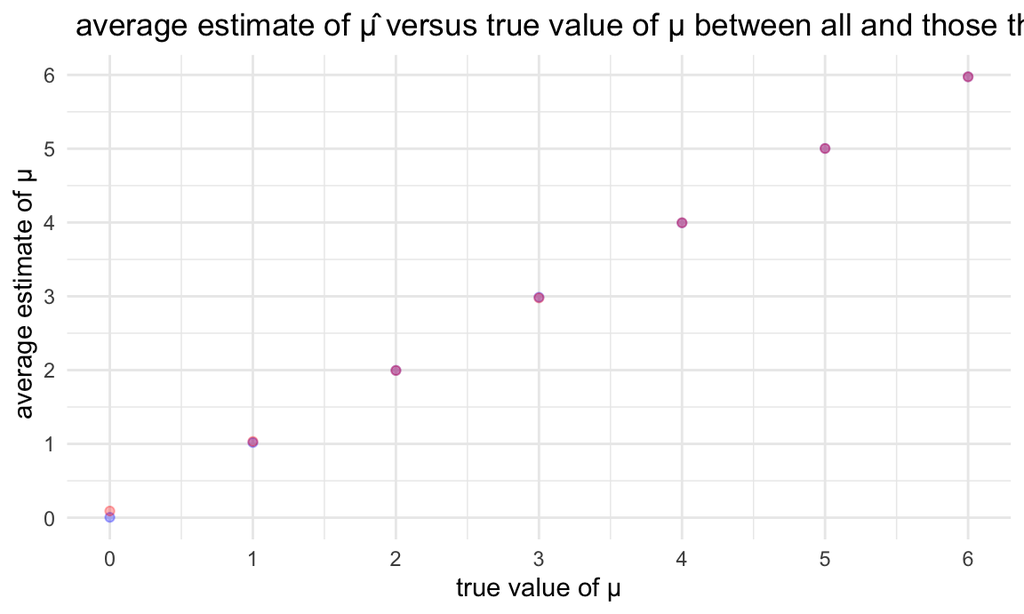

```r
ggplot() +
  geom_point(data = all, aes(x = mu_c,y=mean_mu),
                color = "blue", alpha = 0.3) +
    geom_point(data = reject, aes(x = mu_c,y=mean_mu),
                color = "red", alpha = 0.3) +
  labs(titles = " average estimate of μ̂ versus true value of μ between all and those that are rejected ",
        x = "true value of μ",
       y= " average estimate of μ") +
  theme(legend.position = "right")+
  scale_x_continuous(
    breaks = c(0:6))+
  scale_y_continuous(
    breaks = c(0:6))
```